# Präregistrierung

## Ablauf

[interactive chart not shown]

## Intro

**Inhalte des Workshops:**

- Notwendigkeit der Präregistrierung:
  - Axiomatik des NHST
  - Resultierende Probleme
- Durchführung der Präregistrierung:
  - OSF: Möglichkeiten & Stolpersteine
  - OSF: Do it yourself

**Umsetzung des Workshops:**

- Gerne viel Eigenaktivität!
  - Produktive Heterogenität 😊
  - Hoffentlich nicht zu überformend

## Kurze Survey

Bitte beantworten Sie die Fragen auf pollev.com/merk

[interactive chart not shown]

## Weshalb präregistrieren?

## Das NHSTF

- NHSTF = Nullhypothesen Signifikanztest Framework
- \(\text{p-Wert} \equiv P[E|H_0]\) wobei \(E\) als vorliegendes oder noch stärker gegen \(H_0\) sprechendes empirisches Ereignis definiert wird (Eid, Gollwitzer, & Schmitt, 2013)
- Probleme:
  - Bewusstes Fehlverhalten wie "cherry-picking, data dredging, significance chasing, significance questing, selective inference, p-hacking" … (hier außer Acht)
  - Inhaltsarmut: *"parody of falsificationism in which straw-man null hypothesis A is rejected"* (Gelman, 2016)
  - Multiple comparisons
  - Degrees of freedom (Simmons, Nelson, & Simonsohn, 2011): *"This ‘what would have been done under other possible datasets’ is central to the definition of p-value.” The concern is […] multiple potential comparisons." (Gelman, 2016)*

## Multiple Comparisons

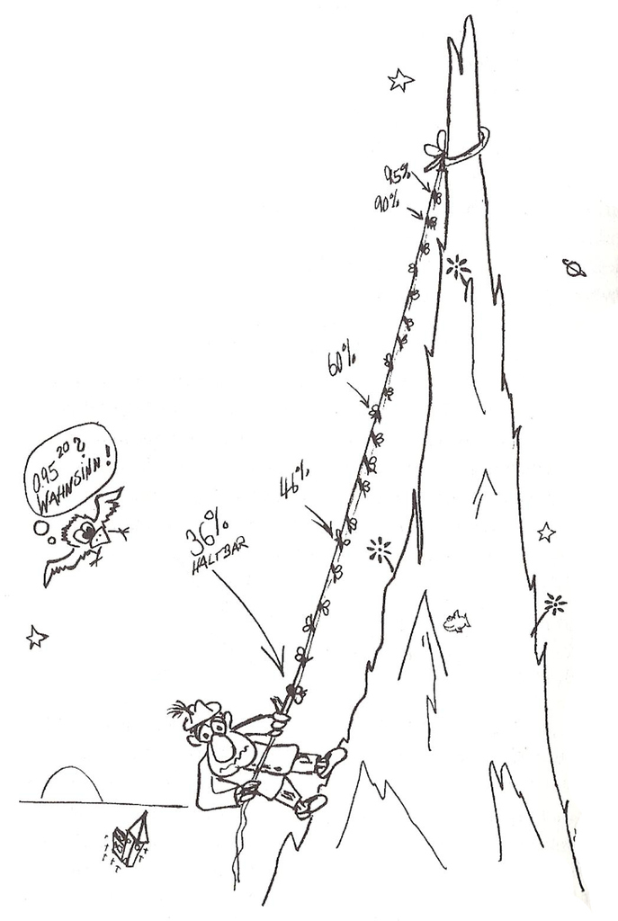

https://wikis.fu-berlin.de/display/fustat

## Freiheitsgrade I

Beispiele:

- Faktor- oder Summenscore?
- latent oder manifest?
- Cronbach oder McDonald?,
- mit neuem Item oder ohne?
- Operationalisierung A oder B?
- Imputationen oder FIML?
- Multivariat oder mehrfach univarat?
- 1-PL, 2-PL oder 3-PL?

## Freiheitsgrade II

Beispiel aus Simmons et al (2011)

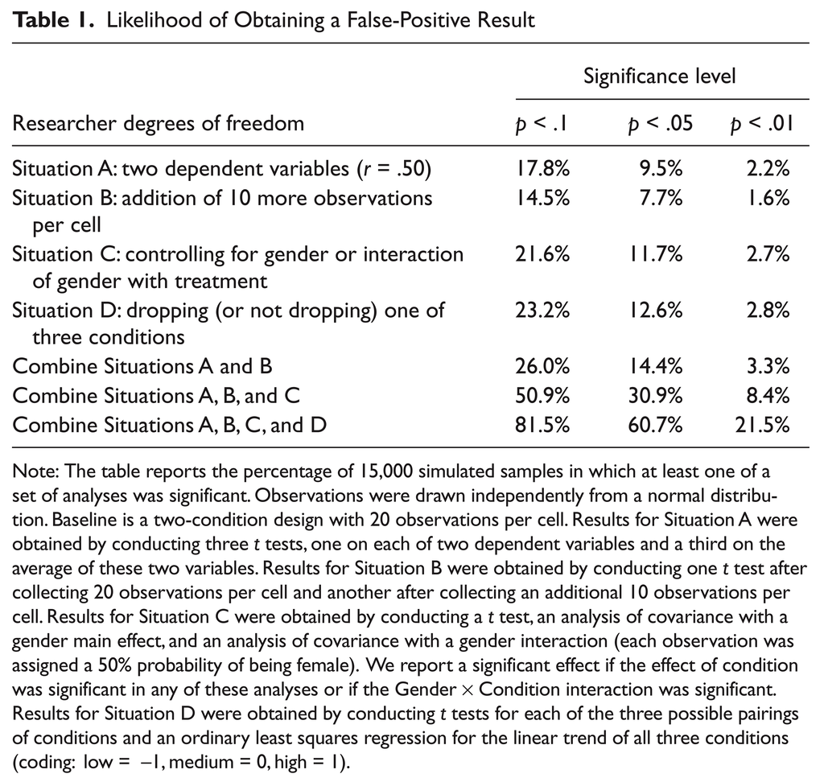

## Lösungsvorschlag I: (Simmons et al., 2011)

Requirements for authors

1. Authors must decide the rule for terminating data collection before data collection begins and report this rule in the article.
2. Authors must collect at least 20 observations per cell or else provide a compelling cost-of-data-collection justification.
3. Authors must list all variables collected in a study.
4. Authors must report all experimental conditions, including failed manipulations.
5. If observations are eliminated, authors must also report what the statistical results are if those observations are included.
6. If an analysis includes a covariate, authors must report the statistical results of the analysis without the covariate.

## Lösungsvorschlag II: (Simmons, Nelson, & Simonsohn, 2012)

21 word solution:

> *We report how we determined our sample size, all data exclusions (if any), all manipulations, and all measures in the study.*

(auch Bestandteil des [Commitment to Research Transparency](http://www.researchtransparency.org/))

## Lösungsvorschlag III: Präregistrierung

- 8-Fragenversion von aspredicted.org
- Preregistration Challenge des OSF
- Vorschlag von van't Veer und Giner-Sorolla (A. E. van ’t Veer & Giner-Sorolla, 2016)
- Vorschlag von Brandt et al (Brandt et al., 2014)

## Arbeitsgruppen I (Tiere): Präregistrierungsformulare

Vorschläge für den Austausch:

- Welchen Forschungsarbeiten gehen Sie gerade nach?
- Welche Erfahrungen haben Sie bisher mit Präregistrierung gemacht?
- Welche Unterschiede zeigen die Präregistrierungsformulare?
- Welche praktischen oder theoretischen Fragen zur Präregistrierung haben Sie?
- Wie würde eine Präregistrierung für ihr aktuelles Vorhaben aussehen? Welche Schwierigkeiten würde diese Präregistrierung aufwerfen?

## Spezifische Open Science Features

- Lizenzierungen
- DOIs für Registrierungen
- PrePrint-Server
- Versionsmanagement
- Usage Analytics
- Wiki
- Sophistizierter API der programmatischen Zugriff erlaubt `{osfr}`, `{pyosf}`
- Anonymisierte View-Only-Links

## Frage- und Hands-On-runde OSF

- Haben Sie Fragen zum OSF?
- Wollen Sie gleich das OSF ausprobieren?
  - Registrieren
  - Demo-Projekte anlegen
  - Demo-Projekte testen
  - Third-Parties ausprobieren
  - Registration anlegen
  - View Only Links testen
  - `{osfr}` ausprobieren

## Arbeitsgruppen II (Pflanzen): Where to go next?

Diskussionsvorschläge:

- Wo sehen Sie in Ihrem konkreten Arbeitsumfeld Chancen und Probleme der Präregistrierung?
- Wo sehen Sie in Ihrem konkreten Arbeitsumfeld Katalysatoren und Stolpersteine für die Umsetzung von Präregistrierungen?

## Literatur

Brandt, M. J., Ijzerman, H., Dijksterhuis, A., Farach, F. J., Geller, J., Giner-Sorolla, R., … van ’t Veer, A. (2014). The Replication Recipe: What makes for a convincing replication? *Journal of Experimental Social Psychology*, *50*(1), 217–224.

Eid, M., Gollwitzer, M., & Schmitt, M. (2013). *Statistik und Forschungsmethoden: Lehrbuch. Mit Online-Materialien* (3rd ed.). Beltz.

Gelman, A. (2016). The problems with p-values are not just with p-values: My comments on the recent ASA statement. Retrieved from http://andrewgelman.com/2016/03/07/29212/

Simmons, J. P., Nelson, L. D., & Simonsohn, U. (2011). False-positive psychology: Undisclosed flexibility in data collection and analysis allows presenting anything as significant. *Psychological Science*, *22*(11), 1359–1366.

Simmons, J. P., Nelson, L. D., & Simonsohn, U. (2012). A 21 Word Solution. *SSRN Electronic Journal*.

van ’t Veer, A. E., & Giner-Sorolla, R. (2016). Pre-registration in social psychology—A discussion and suggested template. *Journal of Experimental Social Psychology*, *67*, 2–12.